# Homework 4: Classification with Logistic Regression & LASSO

STAT 253

# Data Context

Load the packages and data you’ll need for your analysis:

```r
# Load packages
library(tidyverse)
library(tidymodels)
```

Next, load & process weather data for Sydney. For simplicity, we’ll keep only days with complete information (i.e., no missing values).

```r
library(rattle) # load package that weather data come from

data("weatherAUS") # load weather data

# create new sydney data
sydney <- weatherAUS %>%
  filter(Location == "Sydney", !is.na(RainTomorrow)) %>%  # keeps only observations in Sydney that are not missing info about whether it rained the next day
  select(-Location, -Date, -RISK_MM, -WindGustDir, -WindGustSpeed) %>% # removes variables we won't use for prediction
  na.omit() # removes all rows with any missing values for remaining predictors
```

Although we won’t provide feedback on this part of the assignment, you should pause and make sure you understand what each line of code is doing above. Add comments to the end of each line to denote what is happening.

Take a look at the data:

```r
# There are 18 possible predictors of RainTomorrow!
head(sydney, 3)
```

```
# A tibble: 3 × 19
  MinTemp MaxTemp Rainfall Evaporation Sunshine WindDir9am WindDir3pm
    <dbl>   <dbl>    <dbl>       <dbl>    <dbl> <ord>      <ord>
1    19.5    22.4     15.6         6.2      0   S          SSW
2    19.5    25.6      6           3.4      2.7 W          E
3    21.6    24.5      6.6         2.4      0.1 ESE        ESE
# ℹ 12 more variables: WindSpeed9am <dbl>, WindSpeed3pm <dbl>,
#   Humidity9am <int>, Humidity3pm <int>, Pressure9am <dbl>, Pressure3pm <dbl>,
#   Cloud9am <int>, Cloud3pm <int>, Temp9am <dbl>, Temp3pm <dbl>,
#   RainToday <fct>, RainTomorrow <fct>
```

```r
dim(sydney)
```

```
[1] 3828   19
```

# Exercises

## Exercise 1: Model building

In this first exercise, you will build and run CV evaluation for 3 different models of `RainTomorrow`. We will apply and interpret the results in later exercises, just focusing on R code here.

### Part a

Build 3 separate logistic regression models of `RainTomorrow`.

**Answer**

It is important to have the reference level be the Y = 0, or the category that is NOT of interest.

```r
# STEP 0: Organize the RainTomorrow categories
# (Ensure that "Yes" is treated as the category of interest, and "No" is not)
sydney <- sydney %>%
  mutate(RainTomorrow = relevel(RainTomorrow, ref = "No"))
```

```r
# STEP 1: Specify the logistic regression algorithm
# You will use this for all 3 models!
logistic_spec <- logistic_reg() %>%
  set_mode("classification") %>%
  set_engine("glm")
```

```r
# STEP 2: Build the 3 models (take note of the predictors in each)
# Since we don't have any pre-processing steps, we can skip the recipe and workflow steps!
model_1 <- logistic_spec %>%
  fit(RainTomorrow ~ RainToday, data = sydney)

model_2 <- logistic_spec %>%
  fit(RainTomorrow ~ Humidity9am, data = sydney)

model_4 <- logistic_spec %>%
  fit(RainTomorrow ~ ., data = sydney)
```

### Part b

Calculate the 10-fold CV estimates of overall accuracy, sensitivity, and specificity for each of `model_1`, `model_2`, and `model_4`.

**Answer**

```r
# CV for model_1
set.seed(253)
model_1_cv <- logistic_spec %>%
  fit_resamples(
    RainTomorrow ~ RainToday,
    resamples = vfold_cv(sydney, v = 10),
    control = control_resamples(save_pred = TRUE, event_level = 'second'),
    metrics = metric_set(accuracy, sensitivity, specificity)
)
```

```r
# CV for model_2
# Store as model_2_cv
set.seed(253)
model_2_cv <- logistic_spec %>%
  fit_resamples(
    RainTomorrow ~ Humidity9am,
    resamples = vfold_cv(sydney, v = 10),
    control = control_resamples(save_pred = TRUE, event_level = 'second'),
    metrics = metric_set(accuracy, sensitivity, specificity)
)
```

```r
# CV for model_4
# Store as model_4_cv
set.seed(253)
model_4_cv <- logistic_spec %>%
  fit_resamples(
    RainTomorrow ~ .,
    resamples = vfold_cv(sydney, v = 10),
    control = control_resamples(save_pred = TRUE, event_level = 'second'),
    metrics = metric_set(accuracy, sensitivity, specificity)
)
```

## Exercise 2: `model_1` interpretation & prediction

`model_1` models whether or not it will rain *tomorrow* by whether or not it rained *today*, a *categorical* predictor. Let’s explore.

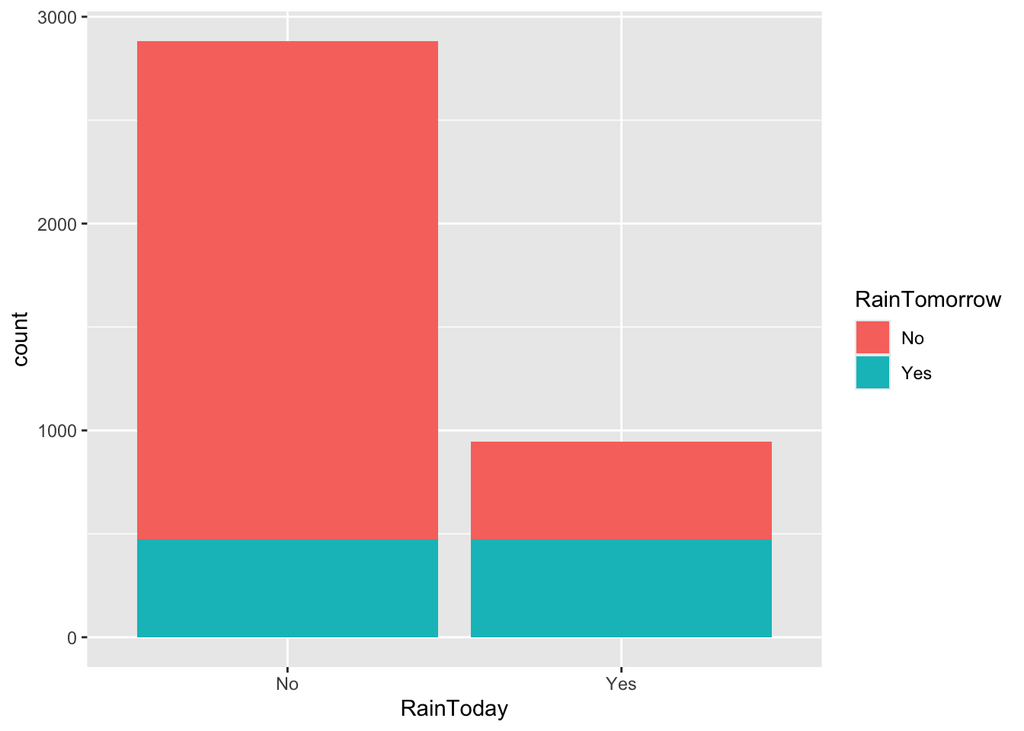

```r
# Plot the relationship
ggplot(sydney, aes(x = RainToday, fill = RainTomorrow)) +
  geom_bar()
```

### Part a

You built `model_1` in Exercise 1. Print the coefficients table here.

**Answer**

```r
# model_1 coefficients
model_1 %>%
  tidy()
```

```
# A tibble: 2 × 5
  term         estimate std.error statistic   p.value
  <chr>           <dbl>     <dbl>     <dbl>     <dbl>
1 (Intercept)     -1.62    0.0502     -32.3 2.46e-229
2 RainTodayYes     1.63    0.0822      19.9 5.93e- 88
```

### Part b

How can we interpret the `RainTodayYes` coefficient on the LOG(ODDS) scale? *Select the correct structure and fill in the blank. Delete all other options.*

- For every extra hour of rain today, the log(odds of rain tomorrow) multiply by ___.
- For every extra hour of rain today, the log(odds of rain tomorrow) increase by ___.
- The log(odds of rain tomorrow) are ____ times higher if it rains today than if it doesn’t rain today.
- The log(odds of rain tomorrow) increase by ____ if it rains today, versus if it doesn’t rain today.

**Answer**

The log(odds of rain tomorrow) increase by **1.63** if it rains today, versus if it doesn’t rain today.

### Part c

How can we interpret the `RainTodayYes` coefficient on the ODDS scale? *Select the correct structure and fill in the blank. Delete all other options.*

- For every extra hour of rain today, the odds of rain tomorrow multiply by ___.
- For every extra hour of rain today, the odds of rain tomorrow increase by ___.
- The odds of rain tomorrow are ____ times higher if it rains today than if it doesn’t rain today.
- The odds of rain tomorrow increase by ____ if it rains today, versus if it doesn’t rain today.

**Answer**

The odds of rain tomorrow are **roughly 5** times higher if it rains today than if it doesn’t rain today.

```r
exp(1.63)
```

```
[1] 5.103875
```

### Part d

Consider two new data points:

```r
new_days <- data.frame(Day = c(1, 2), RainToday = c("No", "Yes"))
new_days
```

```
  Day RainToday
1   1        No
2   2       Yes
```

Use `model_1` to calculate the probability of rain tomorrow for these new data points. *Do this from scratch first (using the model coefficients), and then confirm your calculations using a built-in R function.*

```r
# Probability of rain on Day 1 (calculate from scratch)

# Probability of rain on Day 2 (calculate from scratch)

# Confirm calculations using a built-in R function
```

**Answer**

```r
# Probability of rain on Day 1 (calculate from scratch)
log_odds <- -1.62 + 1.63*0
odds <- exp(log_odds)
probability <- odds / (odds + 1)
probability
```

```
[1] 0.1652049
```

```r
# Probability of rain on Day 2 (calculate from scratch)
log_odds <- -1.62 + 1.63*1
odds <- exp(log_odds)
probability <- odds / (odds + 1)
probability
```

```
[1] 0.5025
```

```r
# Confirm calculations using a built-in R function
# THE PROBABILITY CALCULATIONS ARE IN THE .pred_Yes COLUMN
model_1 %>%
  augment(new_data = new_days)
```

```
# A tibble: 2 × 5
  .pred_class .pred_No .pred_Yes   Day RainToday
  <fct>          <dbl>     <dbl> <dbl> <chr>
1 No             0.835     0.165     1 No
2 Yes            0.497     0.503     2 Yes
```

### Part e

Suppose we used `model_1` with a 0.5 probability threshold to classify whether it rains tomorrow:

- If the probability of rain tomorrow is at least 0.5, predict rain tomorrow.
- Otherwise, predict no rain.

Translate this rule into a statement about `RainToday`. (Remember that this predictor can only be Yes or No!)

- If ___, predict rain tomorrow.
- Otherwise, predict no rain.

**Answer**

This follows from part d. If it rains today, the probability of rain tomorrow is 0.503, which is greater than 0.5 so we predict rain tomorrow. If it doesn’t rain today, the probability of rain tomorrow is 0.165, which is less than 0.5 so we predict no rain tomorrow. Thus…

- If **it rains today**, predict rain tomorrow.
- Otherwise, predict no rain.

## Exercise 3: `model_1` in-sample evaluation

How good is the *in-sample* performance of our above `model_1` classification rule? Let’s explore.

### Part a

Obtain the in-sample confusion matrix.

**Answer**

```r
model_1_confusion <- model_1 %>%
  augment(new_data = sydney) %>%
  conf_mat(truth = RainTomorrow, estimate = .pred_class)

model_1_confusion
```

```
          Truth
Prediction   No  Yes
       No  2408  475
       Yes  470  475
```

### Part b

Use the confusion matrix (from scratch) to calculate the in-sample overall accuracy, sensitivity, and specificity.

```r
# Overall accuracy

# Sensitivity

# Specificity
```

**Answer**

```r
# Overall accuracy
(2408 + 475) / (2408 + 475 + 475 + 470)
```

```
[1] 0.7531348
```

```r
# Sensitivity
475 / (475 + 475)
```

```
[1] 0.5
```

```r
# Specificity
2408 / (2408 + 470)
```

```
[1] 0.8366921
```

### Part c

Confirm your calculations from Part b using the `summary()` function.

**Answer**

See rows 1, 3, and 4 in the output below.

```r
summary(model_1_confusion, event_level = "second")
```

```
# A tibble: 13 × 3
   .metric              .estimator .estimate
   <chr>                <chr>          <dbl>
 1 accuracy             binary         0.753
 2 kap                  binary         0.337
 3 sens                 binary         0.5
 4 spec                 binary         0.837
 5 ppv                  binary         0.503
 6 npv                  binary         0.835
 7 mcc                  binary         0.337
 8 j_index              binary         0.337
 9 bal_accuracy         binary         0.668
10 detection_prevalence binary         0.247
11 precision            binary         0.503
12 recall               binary         0.5
13 f_meas               binary         0.501
```

### Part d

*Interpret* the overall accuracy, sensitivity, and specificity.

- overall accuracy:
- sensitivity:
- specificity:

**Answer**

## Exercise 4: Going big

Whereas `model_1` only uses 1 predictor of `RainTomorrow`, `model_4` uses all 18 possible predictors! Let’s explore the quality of the `model_4` classifications.

### Part a

Calculate the *in-sample* *overall accuracy* of using `model_4` with a 0.5 probability cut-off (the default) to predict `RainTomorrow`. You can use built-in R functions!

**Answer**

```r
# NOTE: You can split this into multiple steps!!!
# also NOTE: I'm filtering to just focus on the metric we want (accuracy) but this isn't strictly necessary

model_4 %>%
  augment(new_data = sydney) %>% # get predictions
  conf_mat(truth = RainTomorrow, estimate = .pred_class) %>% # get the confusion matrix
  summary(event_level = "second") %>% # get metrics (accuracy, sensitivity, specificity, and others)
  filter(.metric == "accuracy") # filter to just print out accuracy
```

```
# A tibble: 1 × 3
  .metric  .estimator .estimate
  <chr>    <chr>          <dbl>
1 accuracy binary         0.845
```

### Part b

You ran the CV process for `model_4` in Exercise 1. Report the *CV* *overall accuracy* of `model_4` here. Pause to convince yourself that you remember how CV metrics are obtained.

**Answer**

```r
model_4_cv %>%
  collect_metrics()
```

```
# A tibble: 3 × 6
  .metric     .estimator  mean     n std_err .config
  <chr>       <chr>      <dbl> <int>   <dbl> <chr>
1 accuracy    binary     0.837    10 0.00736 Preprocessor1_Model1
2 sensitivity binary     0.566    10 0.0168  Preprocessor1_Model1
3 specificity binary     0.928    10 0.00398 Preprocessor1_Model1
```

### Part c

Do these metrics provide evidence that `model_4` is overfit to our sample data? Explain.

**Answer**

No. Our model does similarly well at predicting rain for new days than the days in our sample.

## Exercise 5: `model_4` in-sample evaluation continued

For every day in the data set, `model_4_predictions` stores the observed `RainTomorrow` outcome and the predicted *probability* of rain calculated by `model_4`:

```r
model_4_predictions <- model_4 %>%
  augment(new_data = sydney) %>%
  select(RainTomorrow, .pred_Yes)

head(model_4_predictions)
```

```
# A tibble: 6 × 2
  RainTomorrow .pred_Yes
  <fct>            <dbl>
1 Yes              0.920
2 Yes              0.582
3 Yes              0.900
4 Yes              0.896
5 Yes              0.322
6 Yes              0.921
```

In the previous exercise, we turned these probabilities into binary Yes / No predictions of rain using a 0.5 probability threshold.

But we don’t *have* to use 0.5! Let’s explore this idea.

### Part a

Using the `model_4_predictions` info:

- construct a boxplot of the probability predictions vs the actual `RainTomorrow` outcomes for all days in our dataset; AND
- draw a horizontal line at the approximate probability cut-off that would *maximize* sensitivity *while* maintaining a specificity of at least 75%. HINT: `geom_hline(yintercept = ___)`

**Answer**

To maximize the sensitivity, we want the lowest threshold while still being above the top of the box for No Rain. A threshold of about 0.185 seems to do this.

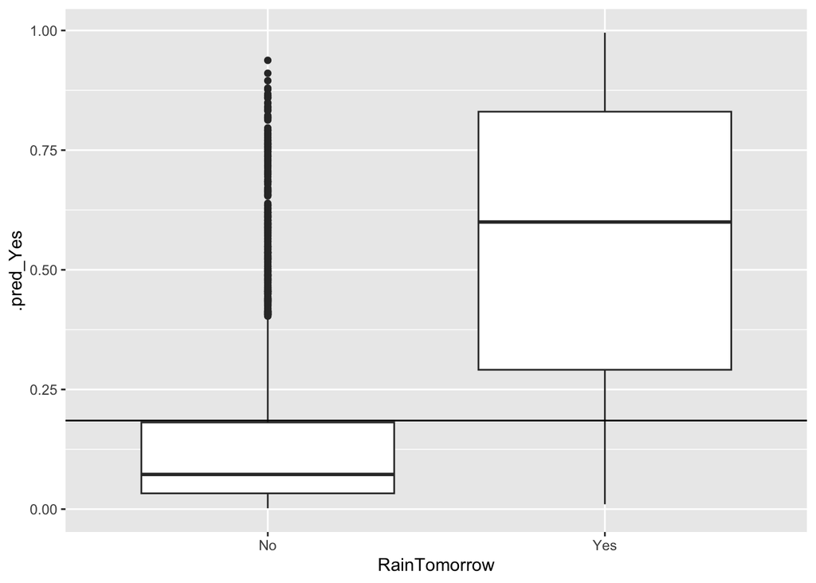

```r
model_4_predictions %>%
  ggplot(aes(y = .pred_Yes, x = RainTomorrow)) +
  geom_boxplot() +
  geom_hline(yintercept = 0.185)
```

NOTE: The placement of the horizontal threshold may vary a little, but should be close to the top of the “No” box

### Part b

We don’t have to guess at probability thresholds, or test them out one by one! `roc_curve()` calculates sensitivity and specificity for a *range* of thresholds between 0 and 1. Adapt the code below to identify a probability threshold that would *maximize* sensitivity *while* maintaining a specificity of at least 75%.

(This should be consistent with your visual approximation in Part b.) **Only print ONE appropriate threshold row** (eg using `head(1)`), **NOT all rows.**

```r
# NOTE the information needed to run this function!
model_4_predictions %>%
  roc_curve(truth = RainTomorrow, .pred_Yes, event_level = "second")
```

**Answer**

```r
# NOTE the information needed to run this function!
model_4_predictions %>%
  roc_curve(truth = RainTomorrow, .pred_Yes, event_level = "second") %>%
  filter(specificity >= 0.75) %>% # keep only those thresholds leading to specificity at or above 0.75
  arrange(desc(sensitivity)) %>% # then sort by *sensitivity*
  head(1) # take the top entry (will have highest sensitivity)
```

```
# A tibble: 1 × 3
  .threshold specificity sensitivity
       <dbl>       <dbl>       <dbl>
1      0.181       0.750       0.836
```

```r
# another way to do this:
# NOTE that slice_max keeps ties
model_4_predictions %>%
  roc_curve(truth = RainTomorrow, .pred_Yes, event_level = "second") %>%
  filter(specificity >= 0.75) %>%
  slice_max(sensitivity, n = 1)
```

```
# A tibble: 3 × 3
  .threshold specificity sensitivity
       <dbl>       <dbl>       <dbl>
1      0.181       0.750       0.836
2      0.182       0.751       0.836
3      0.182       0.751       0.836
```

### Part c

Construct the ROC curve and calculate its AUC. Simply take note of the code here. It’s new!

```r
# ROC curve
model_4_predictions %>%
  roc_curve(truth = RainTomorrow, .pred_Yes, event_level = "second") %>%
  autoplot()

# AUC
model_4_predictions %>%
  roc_auc(truth = RainTomorrow, .pred_Yes, event_level = "second")
```

**Answer**

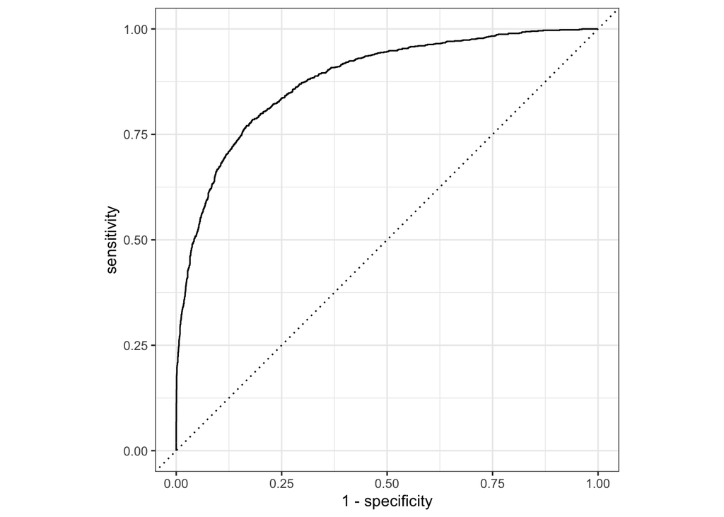

```r
# ROC curve
model_4_predictions %>%
  roc_curve(truth = RainTomorrow, .pred_Yes, event_level = "second") %>%
  autoplot()
```

```r
# AUC
model_4_predictions %>%
  roc_auc(truth = RainTomorrow, .pred_Yes, event_level = "second")
```

```
# A tibble: 1 × 3
  .metric .estimator .estimate
  <chr>   <chr>          <dbl>
1 roc_auc binary         0.880
```

### Part d

Interpret the AUC in the context of this analysis.

**Answer**

Our model can correctly distinguish a rain and no rain day 88% of the time.

## Exercise 6: LASSO!

`model_1` and `model_2` both use only *1* possible predictor of `RainTomorrow`. And `model_4` uses all *18* possible predictors. Something in between these 2 extremes might be better. Luckily, the LASSO algorithm can be used in the classification setting! Just as in the regression setting, LASSO shrinks the $β$ coefficients in the logistic regression model toward / to 0 (thus can kick out predictors):

log(odds of rain tomorrow) = $β0$ + $β1x1$ + $β2x2$ + $⋯$

### Part a

Build 50 LASSO models of `RainTomorrow` using all possible predictors. Try a range of $λ$ penalty parameters from $10−2$ to $10−0.75$ (i.e. from 0.01 to ~0.18). Use 10-fold CV to evaluate each model with respect to its overall accuracy.

NOTE: You’ll need to adapt our LASSO code from the regression setting using some of our new classification code. You can do it!

```r
# STEP 1: Specify the LASSO algorithm
```

```r
# STEP 2: Variable recipe
# Remember that the LASSO requires us to pre-process categorical predictors
```

```r
# STEP 3: Workflow (algorithm + recipe)
```

```r
# STEP 4: Estimate 50 LASSO models
```

**Answer**

```r
# STEP 1: Specify the LASSO algorithm
# NOTE the new model type (logistic_reg) and mode ("classification")
lasso_spec <- logistic_reg() %>%
  set_mode("classification") %>%
  set_engine("glmnet") %>%
  set_args(mixture = 1, penalty = tune())
```

```r
# STEP 2: Variable recipe
# Remember that the LASSO requires us to pre-process categorical predictors
variable_recipe <- recipe(RainTomorrow ~ ., data = sydney) %>%
  step_dummy(all_nominal_predictors())
```

```r
# STEP 3: Workflow (algorithm + recipe)
lasso_workflow <- workflow() %>%
  add_recipe(variable_recipe) %>%
  add_model(lasso_spec)
```

```r
# STEP 4: Estimate 50 LASSO models
set.seed(253)
lasso_models <- lasso_workflow %>%
  tune_grid(
    grid = grid_regular(penalty(range = c(-2, -0.75)), levels = 50),
    resamples = vfold_cv(sydney, v = 10),
    # You can use, but don't need, the control line since we're not calculating sensitivity or specificity
    #control = control_resamples(save_pred = TRUE, event_level = 'second'),
    metrics = metric_set(accuracy)
  )
```

### Part b

Plot the CV accuracy rate versus $λ$ for the 50 LASSO models.

**Answer**

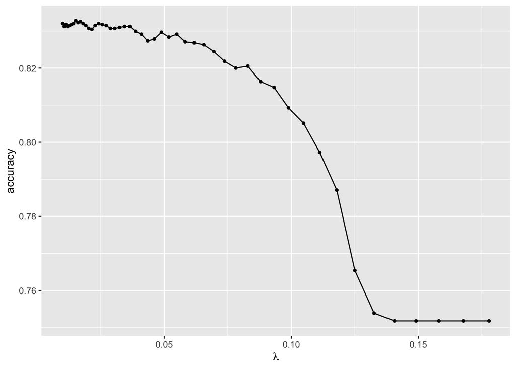

```r
lasso_models %>%
  autoplot() +
  scale_x_continuous() +
  labs(x = expression(lambda))
```

### Part c

Use the plot from Part b to address the impact of increasing $λ$. Be sure to connect what’s happening to the model itself as $λ$ increases (is it getting more or less simple?) with the corresponding impact on the overall accuracy on the model’s rain classifications.

**Answer**

As $λ$ increases, the model becomes more and more simple (with fewer predictors). When it becomes too simple, the overall classification accuracy decreases.

### Part d

Finalize your LASSO model, prioritizing parsimony. Save this as `model_3`.

**Answer**

```r
parsimonious_penalty <- lasso_models %>%
  select_by_one_std_err(metric = "accuracy", desc(penalty))
parsimonious_penalty
```

```
# A tibble: 1 × 2
  penalty .config
    <dbl> <chr>
1  0.0655 Preprocessor1_Model33
```

```r
model_3 <- lasso_workflow %>%
  finalize_workflow(parameters = parsimonious_penalty) %>%
  fit(data = sydney)
```

Remember: the `desc()` step in `select_by_one_std_err` implies that larger values of the penalty correspond to a simpler model. That’s still true here (b/c LASSO) even though we’re using a different evaluation metric.

### Part e

Print out the final LASSO coefficients. Only include coefficients for the predictors that *remain* in the model, i.e. those that have non-zero coefficients. HINT: != is “not equal to” in R.

**Answer**

```r
model_3 %>%
  tidy() %>%
  filter(estimate != 0)
```

```
# A tibble: 5 × 3
  term          estimate penalty
  <chr>            <dbl>   <dbl>
1 (Intercept)    -1.87    0.0655
2 Sunshine       -0.136   0.0655
3 Humidity3pm     0.0248  0.0655
4 Cloud3pm        0.0405  0.0655
5 RainToday_Yes   0.157   0.0655
```

## Exercise 7: Pick a model!

We now have 4 different models of `RainTomorrow`:

[output not shown]

### Part a

Report the CV overall accuracy rates for all 4 models. List the rates here, and include your corresponding code in the chunk below. NOTE: You already performed the CV processes above. Don’t redo that work. Just pull out the relevant metrics.

```r
# model_1 CV accuracy


# model_2 CV accuracy


# model_3 CV accuracy


# model_4 CV accuracy
```

**Answer**

- `model_1` CV accuracy = 0.744
- `model_2` CV accuracy = 0.761
- `model_3` CV accuracy = 0.826
- `model_4` CV accuracy = 0.837

```r
# model_1 CV metrics
# NOTE: the filter step pulls out the relevant metric (accuracy)
model_1_cv %>%
  collect_metrics() %>%
  filter(.metric == "accuracy")
```

```
# A tibble: 1 × 6
  .metric  .estimator  mean     n std_err .config
  <chr>    <chr>      <dbl> <int>   <dbl> <chr>
1 accuracy binary     0.744    10 0.00877 Preprocessor1_Model1
```

```r
# model_2 CV metrics
model_2_cv %>%
  collect_metrics() %>%
  filter(.metric == "accuracy")
```

```
# A tibble: 1 × 6
  .metric  .estimator  mean     n std_err .config
  <chr>    <chr>      <dbl> <int>   <dbl> <chr>
1 accuracy binary     0.761    10 0.00605 Preprocessor1_Model1
```

```r
# model_3 CV metrics
# NOTE: this filter pulls out the results for just our chosen lambda
lasso_models %>%
  collect_metrics() %>%
  filter(penalty == parsimonious_penalty$penalty)
```

```
# A tibble: 1 × 7
  penalty .metric  .estimator  mean     n std_err .config
    <dbl> <chr>    <chr>      <dbl> <int>   <dbl> <chr>
1  0.0655 accuracy binary     0.826    10 0.00753 Preprocessor1_Model33
```

```r
# model_4 CV metrics
model_4_cv %>%
  collect_metrics() %>%
  filter(.metric == "accuracy")
```

```
# A tibble: 1 × 6
  .metric  .estimator  mean     n std_err .config
  <chr>    <chr>      <dbl> <int>   <dbl> <chr>
1 accuracy binary     0.837    10 0.00736 Preprocessor1_Model1
```

### Part b

Complete the code below to obtain the ROC curve and corresponding AUC for each model. NOTE: Don’t get too distracted by the code. It allows us to plot the ROC curves all on 1 plot for easier comparison. We’ll typically plot ROC curves for one model at a time.

```r
# FIRST: Put all 4 sets of model predictions into one data set
# Label these in the "model" column
all_model_predictions <- rbind(
  augment(model_1, new_data = sydney),
  augment(model_2, new_data = sydney),
  augment(model_3, new_data = sydney),
  augment(model_4, new_data = sydney)
) %>%
  mutate(model = rep(c("model 1", "model 2", "model 3", "model 4"), each = nrow(sydney))) %>%
  select(model, RainTomorrow, .pred_Yes)
```

**Answer**

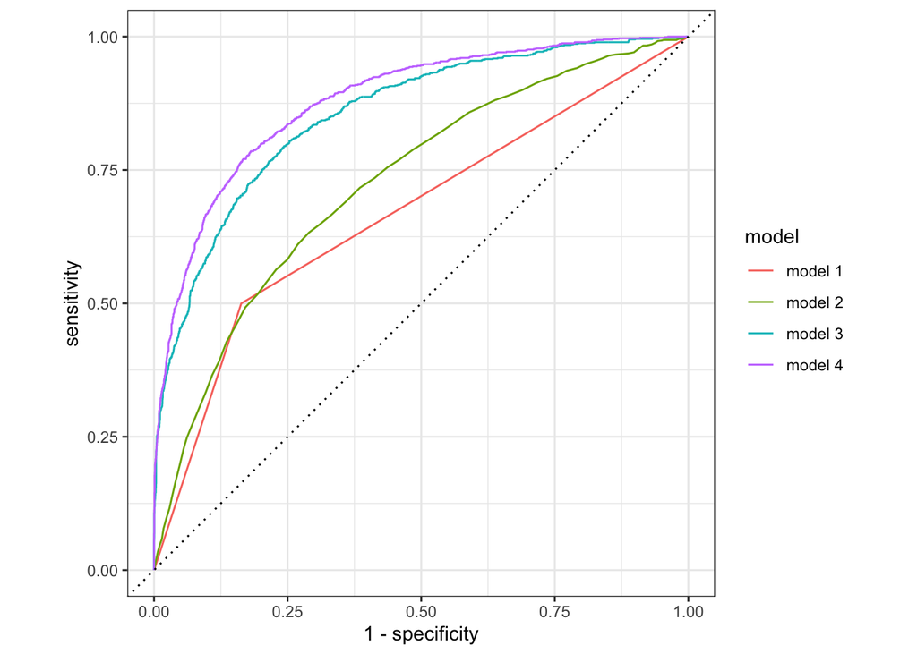

```r
# Plot the ROC curves on one plot
all_model_predictions %>%
  group_by(model) %>%
  roc_curve(truth = RainTomorrow, .pred_Yes, event_level = "second") %>%
  autoplot()
```

```r
# Calculate AUC for all 4 models
all_model_predictions %>%
  group_by(model) %>%
  roc_auc(truth = RainTomorrow, .pred_Yes, event_level = "second")
```

```
# A tibble: 4 × 4
  model   .metric .estimator .estimate
  <chr>   <chr>   <chr>          <dbl>
1 model 1 roc_auc binary         0.668
2 model 2 roc_auc binary         0.726
3 model 3 roc_auc binary         0.855
4 model 4 roc_auc binary         0.880
```

### Part c

In general, what happens to AUC as we add predictors to the model? For example, compare `model_2`, `model_3`, and `model_4`. Pick one option and delete the rest.

- AUC increases
- AUC decreases
- AUC doesn’t change

**Answer**

AUC increases

### Part d

**Answer**

### Part e

You should think about the following:

- Explain why the `model_1` ROC curve is so rigid.
- If you could use only 1 predictor of `RainTomorrow`, `RainToday` or `Humidity9am`, which would it be and why?

**Answer**

The ROC is rigid since the only `model_1` predictor, `RainToday`, has only 2 possible outcomes.

`Humidity9am`. The AUC and CV accuracy are slightly better for `model_2`.

## Exercise 8: Resource Reflection

List the resources you used to complete this assignment (e.g. office hours, textbook, Gen AI, etc.)

Write **3-5 sentences** about which resources were the most useful in helping you complete the assignment.

**Answer**

Answers will vary, but students should list the resouces they used to complete this assignment (e.g. office hours, textbook, NOT Gen AI, etc.) and write 3-5 sentences about which resources were the most useful in helping them complete the assignment.